# Number1and2

Joey Castillo and Justine Sison

7/28/2021

## Question 1

### An article in the Journal of Sound and Vibration [“Measurement of Noise-Evoked Blood Pressure by Means of Averaging Method: Relation between Blood Pressure Rise and PSL” (1991, Vol. 151(3), pp. 383-394)] described a study investigating the relationship between noise exposure and hypertension. The following data are representative of those reported in the article.

```r
df <- data.frame(
  x = c(60,63,65,70,70,70,80,90,80,80,85,89,90,90,90,90,94,100,100,100),
  y = c(1,0,1,2,5,1,4,6,2,3,5,4,6,8,4,5,7,9,7,6))
knitr::kable(df, "pipe", col.name=c("Noise Levels (db)" , "Blood Pressure (mm Hg)"), align=c("c","c","c"))
```

| Noise Levels (db) | Blood Pressure (mm Hg) |
| --- | --- |
| 60 | 1 |
| 63 | 0 |
| 65 | 1 |
| 70 | 2 |
| 70 | 5 |
| 70 | 1 |
| 80 | 4 |
| 90 | 6 |
| 80 | 2 |
| 80 | 3 |
| 85 | 5 |
| 89 | 4 |
| 90 | 6 |
| 90 | 8 |
| 90 | 4 |
| 90 | 5 |
| 94 | 7 |
| 100 | 9 |
| 100 | 7 |
| 100 | 6 |

### A. Draw a scatter diagram of y (blood pressure rise in millimeters of mercury) versus x (sound pressure level in decibels). Does a simple linear regression model seem reasonable in this situation?

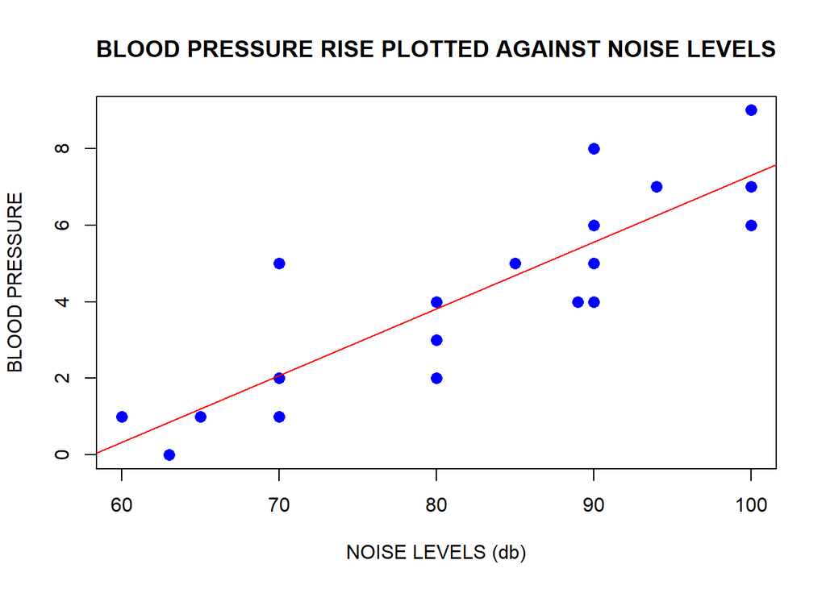

```r
plot(Noise, BP, pch = 16, cex = 1.3, col = "blue", main = "BLOOD PRESSURE RISE PLOTTED AGAINST NOISE LEVELS", xlab = "NOISE LEVELS (db)", ylab = "BLOOD PRESSURE")


abline(lm(BP~Noise), col = "red")
```

A simple linear regression model is appropriate for this situation, as the observed data is steadily increasing without too many outliers.

### B. Fit the simple linear regression model using least squares. Find an estimate of σ2.

For this question, we will use the following values:

$$n=20$$

$$\sum_{i=1}^{20} {x_i} = 1656, \sum_{i=1}^{20} {y_i} = 86$$

$$\sum_{i=1}^{20} {x_i^2} = 140176, \sum_{i=1}^{20} {y_i^2} = 494$$

$$\sum_{i=1}^{20} {x_iy_1} = 7654$$

The form for the simple linear regression model would be:

$$\hat {y} = \hat {\beta_0} + \hat {\beta_1}x$$

However, we don’t know the values of β0 and β1, which are the coefficients. Let us first solve these coefficients.

To compute for β1, let us use the following formulas:

$$S_{xx}=\sum_{i=1}^{20} {x_i^2} - \frac{(\sum_{i=1}^{20} {x_i})^2}{n}$$

$$S_{xy}=\sum_{i=1}^{20} {xy} - \frac{(\sum_{i=1}^{20} {x_i})(\sum_{i=1}^{20} {y_i})}{n}$$
We then substitute the values in these formulas above:

$$S_{xx}=140176 - \frac{(1656)^2}{20} = 140176 - \frac{2742336}{20} = 3059.2$$

$$S_{xy}=7654 - \frac{(1656)(86)}{20} = 7654 - \frac{142416}{20} = 533.2$$

We would now use these values to compute for β1 using this formula:

$$\hat {\beta_1} = \frac{S_{xy}}{S_{xx}} = \frac{533.2}{3059.2} = 0.1742939 \approx 0.1743$$

We would then use the value for β1 along with other values/variables to compute for β0 in this formula:

$$\hat {\beta_0} = \bar y - \hat {\beta_1}\bar x = 4.3 - (0.1742939)(82.8) = -10.1315349 \approx -10.132$$

**Let us now substitute these values to solve for the linear regression model:**

$$\hat {y} = -10.132 + 0.1743x$$

To compute for the estimate of σ2, we would use this formula:

$$\hat \sigma^2 = \frac{SSE}{n-2}$$

However, to solve for SSE, we would use this formula:

$$SSE = \sum_{i=1}^{20} {(y_i - \hat {y_{i1}})^2} = 31.26648$$

We now substitute the values:

$$\hat \sigma^2 = \frac {31.26648}{18} = 1.737027 \approx 1.737$$

The estimate of σ2 or estimated variance is **1.737**

### C. Find the predicted mean rise in blood pressure level associated with a sound pressure level of 85 decibels.

To compute for the mean rise, we just need to substitute the x value from the linear regression model. Since the value of 85 has a unit of decibels, it would mean that the value is in the x-axis of the scatter plot or graph, thus We would let x be 85 to compute for the predicted mean rise. The blood pressure level mean rise would be:

$$\hat {y} = -10.132 + 0.1743(85) = -10.132 + 14.8155 = 4.6835$$

The predicted mean rise in blood pressure level is **4.6835 mm Hg**

## Question 2

### An article in Optical Engineering [“Operating Curve Extraction of a Correlator’s Filter” (2004, Vol. 43, pp. 2775-2779)] reported on the use of an optical correlator to perform an experiment by varying brightness and contrast. The resulting modulation is characterized by the useful range of gray levels. The data follow:

```r
df <- data.frame(
  x1 = c(54, 61, 65, 100, 100,  100,    50, 57, 54),
  x2 = c(56,    80, 70, 50, 65, 80, 25, 35, 26),
  y = c(96, 50, 50, 112,    96, 80, 155,    144,    255))
knitr::kable(df, "pipe", col.name=c("Brightness (%)" , "Contrast (%)", "Useful range (ng)"), align=c("c","c","c"))
```

| Brightness (%) | Contrast (%) | Useful range (ng) |
| --- | --- | --- |
| 54 | 56 | 96 |
| 61 | 80 | 50 |
| 65 | 70 | 50 |
| 100 | 50 | 112 |
| 100 | 65 | 96 |
| 100 | 80 | 80 |
| 50 | 25 | 155 |
| 57 | 35 | 144 |
| 54 | 26 | 255 |

### A. Fit a multiple linear regression model to these data.

For this question, we will use the following values:

$$n=9$$

$$\sum_{i=1}^{9} {x_{i1}} = 641, \sum_{i=1}^{9} {x_{i2}} = 487, \sum_{i=1}^{9} {y_i} = 1038$$

$$\sum_{i=1}^{9} {x_{i1}^2} = 49527, \sum_{i=1}^{9} {x_{i2}^2} = 30087, \sum_{i=1}^{9} {y_i^2} = 152162$$

$$\sum_{i=1}^{9} {x_{i1}x_{i2}} = 36603, \sum_{i=1}^{9} {x_{i1}y_i} = 70012, \sum_{i=1}^{9} {x_{i2}y_i} = 46661$$

The form for the simple linear regression model would be:

$$\hat {y} = \hat {\beta_0} + \hat {\beta_1}x_1 + \hat {\beta_2}x_2$$

However, we don’t know how the values of β0, β1 and β2. To compute for these values, we would use least squares normal Equations:

$$n\hat {\beta_0} + \hat {\beta_1}\sum_{i=1}^{9} {x_{i1}} + \hat {\beta_2}\sum_{i=1}^{9} {x_{i2}} = \sum_{i=1}^{9} {y_i}$$

$$\hat {\beta_0}\sum_{i=1}^{9} {x_{i1}}+\hat {\beta_1}\sum_{i=1}^{9} {x_{i1}^2}+ \hat {\beta_2}\sum_{i=1}^{9} {x_{i1}x_{i2}} = \sum_{i=1}^{9} {x_{i1}y_i}$$

$$\hat {\beta_0}\sum_{i=1}^{9} {x_{i2}}+\hat {\beta_1}\sum_{i=1}^{9} {x_{i1}x_{i2}}+ \hat {\beta_2} \sum_{i=1}^{9} {x_{i2}^2} = \sum_{i=1}^{9} {x_{i2}y_i}$$

We’ll then substitute the previous values or variables whose values were already determined to these equations:

$$9\hat {\beta_0} + 641\hat {\beta_1} + 487\hat {\beta_2} = 1038$$

$$641\hat {\beta_0}+49527\hat {\beta_1}+ 36603\hat {\beta_2} = 70012$$

Now notice that these equations all have similar unknown variables, yet different equations. These equations look very similar to linear equations, having 3 variables. Therefore in order to solve this problem, we would be using systems of linear equation to solve this problem, which would give us the values of the missing variables:

$$\hat \beta_0 = 238.56 \approx 239$$
$$\hat \beta_1 = 0.3339 \approx 0.334$$

$$\hat \beta_2 = -2.7167 \approx -2.72$$

**Let us now substitute these values to solve for or fit the multiple regression model, which would be:**

$$\hat {y} = 239 + 0.334x_1 -2.72 x_2$$

### B. Estimate σ2.

To compute for the estimate of σ2, we would use this formula:

$$\hat \sigma^2 = \frac{SSE}{n-p}$$

the p variable represents the parameters. The number of parameters are 3 (Brightness, Contrast and Useful range), which would mean that p = 3

However, to solve for SSE, we would use this formula:

$$SSE = \sum_{i=1}^{20} {(y_i - \hat {y_{i1}})^2} = 7928.344 \approx 7928$$

We now substitute the values:

$$\hat \sigma^2 = \frac {7928}{9-3} = \frac {7928}{6} = 1321$$

The estimate of σ2 or estimated variance is **1321**

### C. Compute the standard errors of the regression coefficients.

Computing for the standard errors of the regression coefficients requires a lot of Math that are very complicated if solved manually. However, using an external application, we managed to solve the standard errors of each regression coefficients:

$$se(\hat \beta_0) = 45.23$$

$$se(\hat \beta_1) = 0.6763$$

$$se(\hat \beta_2) = 0.6887$$

### D. Predict the useful range when brightness = 80 and contrast = 75.

To compute for the useful range, we just have to substitute the values from the linear regression model. We would then use these values:

$$x_1 = 80$$

$$x_2 = 75$$

Let us then Substitute the given values:

$$\hat{y} = 239 + 0.334(x_1)-2.72(x_2)= 239 + 0.334(80)-2.72(75) = 239 + 26.72 -204 = 61.72$$

The predicted useful range is **61.72**

### E. Test for significance of regression using α=0.05. What is the P-value for this test?

The Z-score for a 0.05 significance level is 1.645. To solve for its p-value, we would use the formula for a right-tailed test and substitute the values:

$$P = [1- \Phi(Z_{0.05})] = 1 - 0.9495 = 0.0505 \approx 0.051$$

The P-value is **0.051**

### F. Construct a t-test on each regression coefficient. What conclusions can you draw about the variables in this model? Use α=0.05.

Declaring our hypotheses for the Brightness and Contrast coefficient tests respectively,

Brightness
$$H_0: \beta_1 = 0 \\
H_1: \beta_1 \ne 0$$

Contrast
$$H_0:\beta_2 = 0 \\
H_1:\beta_2 \ne 0$$

We will be using the formula for test statistic on both hypotheses:

$$t_0 = \frac{\hat\beta}{se(\hat\beta)}$$

Inserting the values, we get:

$\beta_1$:

$$t_1 = \frac{\hat\beta_1}{se(\hat\beta_1)} \\
t_1= \frac{0.3339}{0.6763}\\
t_1=0.4937$$

$\beta_2$:

$$t_2 = \frac{\hat\beta_2}{se(\hat\beta_2)} \\
t_2 = \frac{-2.7167}{0.6887} \\
t_2 = -3.9447 \\$$

Now that we have the respective t-scores for $\beta_1$ and $\beta_2$, we must compare them to the critical value of $t_\frac{\alpha}{2},n-p = 2.4469$. If |$t_1$ or $t_2$|>$t_\frac{\alpha}{2},n-p = 2.4469$, then their respective null hypotheses will be rejected.

Comparing the Values:

$$|t_1| = 0.4937<2.4469 = t_\frac{\alpha}{2},n-p$$
With $\beta_1$’s t-score being lesser than the critical value, it is safe to fail to reject the null hypothesis in this case. This means that Brightness does not have a significant effect on the model.

$$|t_2| = 3.9447 > 2.4469 = t_\frac{\alpha}{2},n-p$$

With $\beta_2$’s t-score being greater than the critical value, it is safe to reject the null hypothesis and accept that Contrast has a significant effect on the model.